# **ATLIQ HOTELS DATA ANALYSIS PROJECT**

**The dataset comprises of 5 files:**

- **fact_bookings**
- **fact_aggregated_bookings**
- **dim_date**
- **dim_hotels**
- **dim_rooms**

### **Data Import and Exploration**

```python
import pandas as pd
```

**>> read bookings file in a dataframe**

```python
df_bookings=pd.read_csv("datasets/fact_bookings.csv")
df_bookings.head(4)
```

|  | booking_id | property_id | booking_date | check_in_date | checkout_date | no_guests | room_category | booking_platform | ratings_given | booking_status | revenue_generated | revenue_realized |
| --- | --- | --- | --- | --- | --- | --- | --- | --- | --- | --- | --- | --- |
| 0 | May012216558RT11 | 16558 | 27-04-22 | 1/5/2022 | 2/5/2022 | -3.0 | RT1 | direct online | 1.0 | Checked Out | 10010 | 10010 |
| 1 | May012216558RT12 | 16558 | 30-04-22 | 1/5/2022 | 2/5/2022 | 2.0 | RT1 | others | NaN | Cancelled | 9100 | 3640 |
| 2 | May012216558RT13 | 16558 | 28-04-22 | 1/5/2022 | 4/5/2022 | 2.0 | RT1 | logtrip | 5.0 | Checked Out | 9100000 | 9100 |
| 3 | May012216558RT14 | 16558 | 28-04-22 | 1/5/2022 | 2/5/2022 | -2.0 | RT1 | others | NaN | Cancelled | 9100 | 3640 |

**>> explore bookings data**

```python
df_bookings.shape
```

```
(134590, 12)
```

```python
df_bookings.room_category.unique()
```

```
array(['RT1', 'RT2', 'RT3', 'RT4'], dtype=object)
```

```python
df_bookings.booking_platform.unique()
```

```
array(['direct online', 'others', 'logtrip', 'tripster', 'makeyourtrip',
       'journey', 'direct offline'], dtype=object)
```

```python
df_bookings.booking_platform.value_counts()
```

```
booking_platform
others            55066
makeyourtrip      26898
logtrip           14756
direct online     13379
tripster           9630
journey            8106
direct offline     6755
Name: count, dtype: int64
```

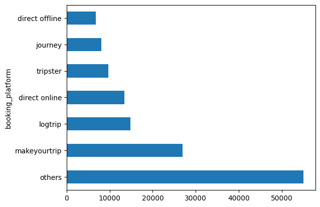

```python
df_bookings.booking_platform.value_counts().plot(kind='barh')
```

```python
df_bookings.describe()
```

|  | property_id | no_guests | ratings_given | revenue_generated | revenue_realized |
| --- | --- | --- | --- | --- | --- |
| count | 134590.000000 | 134587.000000 | 56683.000000 | 1.345900e+05 | 134590.000000 |
| mean | 18061.113493 | 2.036170 | 3.619004 | 1.537805e+04 | 12696.123256 |
| std | 1093.055847 | 1.034885 | 1.235009 | 9.303604e+04 | 6928.108124 |
| min | 16558.000000 | -17.000000 | 1.000000 | 6.500000e+03 | 2600.000000 |
| 25% | 17558.000000 | 1.000000 | 3.000000 | 9.900000e+03 | 7600.000000 |
| 50% | 17564.000000 | 2.000000 | 4.000000 | 1.350000e+04 | 11700.000000 |
| 75% | 18563.000000 | 2.000000 | 5.000000 | 1.800000e+04 | 15300.000000 |
| max | 19563.000000 | 6.000000 | 5.000000 | 2.856000e+07 | 45220.000000 |

```python
df_bookings.revenue_generated.min(),df_bookings.revenue_generated.max()
```

```
(np.int64(6500), np.int64(28560000))
```

```python
df_date=pd.read_csv("datasets/dim_date.csv")
df_hotels=pd.read_csv("datasets/dim_hotels.csv")
df_rooms=pd.read_csv("datasets/dim_rooms.csv")
df_agg_bookings=pd.read_csv("datasets/fact_aggregated_bookings.csv")
```

**>> explore hotels data**

```python
df_hotels.shape
```

```
(25, 4)
```

```python
df_hotels.head(4)
```

|  | property_id | property_name | category | city |
| --- | --- | --- | --- | --- |
| 0 | 16558 | Atliq Grands | Luxury | Delhi |
| 1 | 16559 | Atliq Exotica | Luxury | Mumbai |
| 2 | 16560 | Atliq City | Business | Delhi |
| 3 | 16561 | Atliq Blu | Luxury | Delhi |

```python
df_hotels.category.value_counts()
```

```
category
Luxury      16
Business     9
Name: count, dtype: int64
```

```python
df_hotels.city.value_counts().sort_values()
```

```
city
Delhi        5
Hyderabad    6
Bangalore    6
Mumbai       8
Name: count, dtype: int64
```

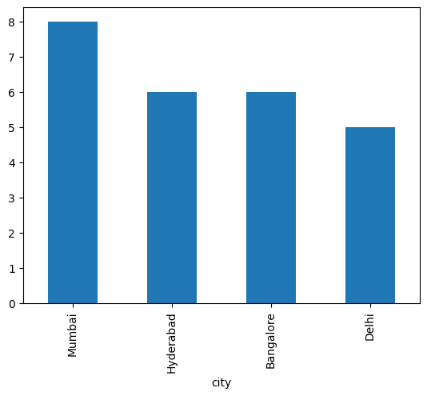

```python
df_hotels.city.value_counts().plot(kind='bar')
```

**>> explore aggregated bookings data and observe trends of successful bookings and capacity by using basic statistics functions**

```python
df_agg_bookings.head()
```

|  | property_id | check_in_date | room_category | successful_bookings | capacity |
| --- | --- | --- | --- | --- | --- |
| 0 | 16559 | 1-May-22 | RT1 | 25 | 30.0 |
| 1 | 19562 | 1-May-22 | RT1 | 28 | 30.0 |
| 2 | 19563 | 1-May-22 | RT1 | 23 | 30.0 |
| 3 | 17558 | 1-May-22 | RT1 | 30 | 19.0 |
| 4 | 16558 | 1-May-22 | RT1 | 18 | 19.0 |

```python
df_agg_bookings.property_id.unique()
```

```
array([16559, 19562, 19563, 17558, 16558, 17560, 19558, 19560, 17561,
       16560, 16561, 16562, 16563, 17559, 17562, 17563, 18558, 18559,
       18561, 18562, 18563, 19559, 19561, 17564, 18560])
```

```python
df_agg_bookings.groupby("property_id") ["successful_bookings"].sum()
```

```
property_id
16558    3153
16559    7338
16560    4693
16561    4418
16562    4820
16563    7211
17558    5053
17559    6142
17560    6013
17561    5183
17562    3424
17563    6337
17564    3982
18558    4475
18559    5256
18560    6638
18561    6458
18562    7333
18563    4737
19558    4400
19559    4729
19560    6079
19561    5736
19562    5812
19563    5413
Name: successful_bookings, dtype: int64
```

```python
df_agg_bookings[df_agg_bookings.successful_bookings>df_agg_bookings.capacity]
```

|  | property_id | check_in_date | room_category | successful_bookings | capacity |
| --- | --- | --- | --- | --- | --- |
| 3 | 17558 | 1-May-22 | RT1 | 30 | 19.0 |
| 12 | 16563 | 1-May-22 | RT1 | 100 | 41.0 |
| 4136 | 19558 | 11-Jun-22 | RT2 | 50 | 39.0 |
| 6209 | 19560 | 2-Jul-22 | RT1 | 123 | 26.0 |
| 8522 | 19559 | 25-Jul-22 | RT1 | 35 | 24.0 |
| 9194 | 18563 | 31-Jul-22 | RT4 | 20 | 18.0 |

```python
df_agg_bookings[df_agg_bookings.capacity==df_agg_bookings.capacity.max()]
```

|  | property_id | check_in_date | room_category | successful_bookings | capacity |
| --- | --- | --- | --- | --- | --- |
| 27 | 17558 | 1-May-22 | RT2 | 38 | 50.0 |
| 128 | 17558 | 2-May-22 | RT2 | 27 | 50.0 |
| 229 | 17558 | 3-May-22 | RT2 | 26 | 50.0 |
| 328 | 17558 | 4-May-22 | RT2 | 27 | 50.0 |
| 428 | 17558 | 5-May-22 | RT2 | 29 | 50.0 |
| ... | ... | ... | ... | ... | ... |
| 8728 | 17558 | 27-Jul-22 | RT2 | 22 | 50.0 |
| 8828 | 17558 | 28-Jul-22 | RT2 | 21 | 50.0 |
| 8928 | 17558 | 29-Jul-22 | RT2 | 23 | 50.0 |
| 9028 | 17558 | 30-Jul-22 | RT2 | 32 | 50.0 |
| 9128 | 17558 | 31-Jul-22 | RT2 | 30 | 50.0 |

92 rows × 5 columns

## **Data Cleaning**

```python
df_bookings.describe()
```

|  | property_id | no_guests | ratings_given | revenue_generated | revenue_realized |
| --- | --- | --- | --- | --- | --- |
| count | 134590.000000 | 134587.000000 | 56683.000000 | 1.345900e+05 | 134590.000000 |
| mean | 18061.113493 | 2.036170 | 3.619004 | 1.537805e+04 | 12696.123256 |
| std | 1093.055847 | 1.034885 | 1.235009 | 9.303604e+04 | 6928.108124 |
| min | 16558.000000 | -17.000000 | 1.000000 | 6.500000e+03 | 2600.000000 |
| 25% | 17558.000000 | 1.000000 | 3.000000 | 9.900000e+03 | 7600.000000 |
| 50% | 17564.000000 | 2.000000 | 4.000000 | 1.350000e+04 | 11700.000000 |
| 75% | 18563.000000 | 2.000000 | 5.000000 | 1.800000e+04 | 15300.000000 |
| max | 19563.000000 | 6.000000 | 5.000000 | 2.856000e+07 | 45220.000000 |

**>> clean data errors**

- no of guests in a booking can not be a negative value, thus we can ignore these records

```python
df_bookings[df_bookings.no_guests<=0]
```

|  | booking_id | property_id | booking_date | check_in_date | checkout_date | no_guests | room_category | booking_platform | ratings_given | booking_status | revenue_generated | revenue_realized |
| --- | --- | --- | --- | --- | --- | --- | --- | --- | --- | --- | --- | --- |
| 0 | May012216558RT11 | 16558 | 27-04-22 | 1/5/2022 | 2/5/2022 | -3.0 | RT1 | direct online | 1.0 | Checked Out | 10010 | 10010 |
| 3 | May012216558RT14 | 16558 | 28-04-22 | 1/5/2022 | 2/5/2022 | -2.0 | RT1 | others | NaN | Cancelled | 9100 | 3640 |
| 17924 | May122218559RT44 | 18559 | 12/5/2022 | 12/5/2022 | 14-05-22 | -10.0 | RT4 | direct online | NaN | No Show | 20900 | 20900 |
| 18020 | May122218561RT22 | 18561 | 8/5/2022 | 12/5/2022 | 14-05-22 | -12.0 | RT2 | makeyourtrip | NaN | Cancelled | 9000 | 3600 |
| 18119 | May122218562RT311 | 18562 | 5/5/2022 | 12/5/2022 | 17-05-22 | -6.0 | RT3 | direct offline | 5.0 | Checked Out | 16800 | 16800 |
| 18121 | May122218562RT313 | 18562 | 10/5/2022 | 12/5/2022 | 17-05-22 | -4.0 | RT3 | direct online | NaN | Cancelled | 14400 | 5760 |
| 56715 | Jun082218562RT12 | 18562 | 5/6/2022 | 8/6/2022 | 13-06-22 | -17.0 | RT1 | others | NaN | Checked Out | 6500 | 6500 |
| 119765 | Jul202219560RT220 | 19560 | 19-07-22 | 20-07-22 | 22-07-22 | -1.0 | RT2 | others | NaN | Checked Out | 13500 | 13500 |
| 134586 | Jul312217564RT47 | 17564 | 30-07-22 | 31-07-22 | 1/8/2022 | -4.0 | RT4 | logtrip | 2.0 | Checked Out | 38760 | 38760 |

```python
df_bookings=df_bookings[df_bookings.no_guests>0]
df_bookings.shape
```

```
(134578, 12)
```

- **outlier removal in revenue generated**

```python
df_bookings.revenue_generated.min(), df_bookings.revenue_generated.max()
```

```
(np.int64(6500), np.int64(28560000))
```

```python
avg, std = df_bookings.revenue_generated.mean(), df_bookings.revenue_generated.std()
avg, std
```

```
(np.float64(15378.036937686695), np.float64(93040.1549314641))
```

```python
higher_limit= avg + 3*std
higher_limit
```

```
np.float64(294498.50173207896)
```

```python
lower_limit= avg - 3*std
lower_limit
```

```
np.float64(-263742.4278567056)
```

```python
df_bookings[df_bookings.revenue_generated>higher_limit]
```

|  | booking_id | property_id | booking_date | check_in_date | checkout_date | no_guests | room_category | booking_platform | ratings_given | booking_status | revenue_generated | revenue_realized |
| --- | --- | --- | --- | --- | --- | --- | --- | --- | --- | --- | --- | --- |
| 2 | May012216558RT13 | 16558 | 28-04-22 | 1/5/2022 | 4/5/2022 | 2.0 | RT1 | logtrip | 5.0 | Checked Out | 9100000 | 9100 |
| 111 | May012216559RT32 | 16559 | 29-04-22 | 1/5/2022 | 2/5/2022 | 6.0 | RT3 | direct online | NaN | Checked Out | 28560000 | 28560 |
| 315 | May012216562RT22 | 16562 | 28-04-22 | 1/5/2022 | 4/5/2022 | 2.0 | RT2 | direct offline | 3.0 | Checked Out | 12600000 | 12600 |
| 562 | May012217559RT118 | 17559 | 26-04-22 | 1/5/2022 | 2/5/2022 | 2.0 | RT1 | others | NaN | Cancelled | 2000000 | 4420 |
| 129176 | Jul282216562RT26 | 16562 | 21-07-22 | 28-07-22 | 29-07-22 | 2.0 | RT2 | direct online | 3.0 | Checked Out | 10000000 | 12600 |

```python
df_bookings[df_bookings.revenue_generated<lower_limit]
```

|  | booking_id | property_id | booking_date | check_in_date | checkout_date | no_guests | room_category | booking_platform | ratings_given | booking_status | revenue_generated | revenue_realized |
| --- | --- | --- | --- | --- | --- | --- | --- | --- | --- | --- | --- | --- |

```python
df_bookings=df_bookings[df_bookings.revenue_generated<higher_limit]
df_bookings.shape
```

```
(134573, 12)
```

```python
df_bookings.revenue_realized.describe()
```

```
count    134573.000000
mean      12695.983585
std        6927.791692
min        2600.000000
25%        7600.000000
50%       11700.000000
75%       15300.000000
max       45220.000000
Name: revenue_realized, dtype: float64
```

```python
higher_limit_rr = df_bookings.revenue_realized.mean() + 3*df_bookings.revenue_realized.std()
higher_limit_rr
```

```
np.float64(33479.358661845814)
```

```python
df_bookings[df_bookings.revenue_realized>higher_limit_rr]
```

|  | booking_id | property_id | booking_date | check_in_date | checkout_date | no_guests | room_category | booking_platform | ratings_given | booking_status | revenue_generated | revenue_realized |
| --- | --- | --- | --- | --- | --- | --- | --- | --- | --- | --- | --- | --- |
| 137 | May012216559RT41 | 16559 | 27-04-22 | 1/5/2022 | 7/5/2022 | 4.0 | RT4 | others | NaN | Checked Out | 38760 | 38760 |
| 139 | May012216559RT43 | 16559 | 1/5/2022 | 1/5/2022 | 2/5/2022 | 6.0 | RT4 | tripster | 3.0 | Checked Out | 45220 | 45220 |
| 143 | May012216559RT47 | 16559 | 28-04-22 | 1/5/2022 | 3/5/2022 | 3.0 | RT4 | others | 5.0 | Checked Out | 35530 | 35530 |
| 149 | May012216559RT413 | 16559 | 24-04-22 | 1/5/2022 | 7/5/2022 | 5.0 | RT4 | logtrip | NaN | Checked Out | 41990 | 41990 |
| 222 | May012216560RT45 | 16560 | 30-04-22 | 1/5/2022 | 3/5/2022 | 5.0 | RT4 | others | 3.0 | Checked Out | 34580 | 34580 |
| ... | ... | ... | ... | ... | ... | ... | ... | ... | ... | ... | ... | ... |
| 134328 | Jul312219560RT49 | 19560 | 31-07-22 | 31-07-22 | 2/8/2022 | 6.0 | RT4 | direct online | 5.0 | Checked Out | 39900 | 39900 |
| 134331 | Jul312219560RT412 | 19560 | 31-07-22 | 31-07-22 | 1/8/2022 | 6.0 | RT4 | others | 2.0 | Checked Out | 39900 | 39900 |
| 134467 | Jul312219562RT45 | 19562 | 28-07-22 | 31-07-22 | 1/8/2022 | 6.0 | RT4 | makeyourtrip | 4.0 | Checked Out | 39900 | 39900 |
| 134474 | Jul312219562RT412 | 19562 | 25-07-22 | 31-07-22 | 6/8/2022 | 5.0 | RT4 | direct offline | 5.0 | Checked Out | 37050 | 37050 |
| 134581 | Jul312217564RT42 | 17564 | 31-07-22 | 31-07-22 | 1/8/2022 | 4.0 | RT4 | makeyourtrip | 4.0 | Checked Out | 38760 | 38760 |

1299 rows × 12 columns

-- **one observation is that all revenue realized fields exceeding mean+3*std are of RT4**

- therefore, analyzing RT4 data

```python
df_bookings[df_bookings.room_category=="RT4"].revenue_realized.describe()
```

```
count    16071.000000
mean     23439.308444
std       9048.599076
min       7600.000000
25%      19000.000000
50%      26600.000000
75%      32300.000000
max      45220.000000
Name: revenue_realized, dtype: float64
```

```python
#mean+ 3*std
23439.308444+ 3*9048.599076
```

```
50585.105672000005
```

-- mean+ 3*std>max value , hence no data outliers are there in reference to revenue realized field

**>> null value check and replace**

```python
df_bookings.isnull().sum()
```

```
booking_id               0
property_id              0
booking_date             0
check_in_date            0
checkout_date            0
no_guests                0
room_category            0
booking_platform         0
ratings_given        77897
booking_status           0
revenue_generated        0
revenue_realized         0
dtype: int64
```

```python
df_agg_bookings.isnull().sum()
```

```
property_id            0
check_in_date          0
room_category          0
successful_bookings    0
capacity               2
dtype: int64
```

```python
df_agg_bookings[df_agg_bookings.capacity.isna()]
```

|  | property_id | check_in_date | room_category | successful_bookings | capacity |
| --- | --- | --- | --- | --- | --- |
| 8 | 17561 | 1-May-22 | RT1 | 22 | NaN |
| 14 | 17562 | 1-May-22 | RT1 | 12 | NaN |

```python
df_agg_bookings.capacity.median()
```

```
np.float64(25.0)
```

```python
df_agg_bookings.capacity.fillna(df_agg_bookings.capacity.median(),inplace=True)
```

```python
df_agg_bookings.loc[[8,14]]
```

|  | property_id | check_in_date | room_category | successful_bookings | capacity |
| --- | --- | --- | --- | --- | --- |
| 8 | 17561 | 1-May-22 | RT1 | 22 | 25.0 |
| 14 | 17562 | 1-May-22 | RT1 | 12 | 25.0 |

```python
df_agg_bookings[df_agg_bookings.successful_bookings>df_agg_bookings.capacity]
```

|  | property_id | check_in_date | room_category | successful_bookings | capacity |
| --- | --- | --- | --- | --- | --- |
| 3 | 17558 | 1-May-22 | RT1 | 30 | 19.0 |
| 12 | 16563 | 1-May-22 | RT1 | 100 | 41.0 |
| 4136 | 19558 | 11-Jun-22 | RT2 | 50 | 39.0 |
| 6209 | 19560 | 2-Jul-22 | RT1 | 123 | 26.0 |
| 8522 | 19559 | 25-Jul-22 | RT1 | 35 | 24.0 |
| 9194 | 18563 | 31-Jul-22 | RT4 | 20 | 18.0 |

```python
df_agg_bookings.shape
```

```
(9200, 5)
```

```python
df_agg_bookings=df_agg_bookings[df_agg_bookings.successful_bookings<=df_agg_bookings.capacity]
df_agg_bookings.shape
```

```
(9194, 5)
```

## **Data Transformation**

Different types:

- create new columns
- normalization
- merging dataframes
- aggregation/grouping

```python
 df_agg_bookings.head()
```

|  | property_id | check_in_date | room_category | successful_bookings | capacity |
| --- | --- | --- | --- | --- | --- |
| 0 | 16559 | 1-May-22 | RT1 | 25 | 30.0 |
| 1 | 19562 | 1-May-22 | RT1 | 28 | 30.0 |
| 2 | 19563 | 1-May-22 | RT1 | 23 | 30.0 |
| 4 | 16558 | 1-May-22 | RT1 | 18 | 19.0 |
| 5 | 17560 | 1-May-22 | RT1 | 28 | 40.0 |

**> create new column: occupancy percent**

```python
df_agg_bookings["occ_pct"]=df_agg_bookings["successful_bookings"]/df_agg_bookings["capacity"]
df_agg_bookings.head()
```

|  | property_id | check_in_date | room_category | successful_bookings | capacity | occ_pct |
| --- | --- | --- | --- | --- | --- | --- |
| 0 | 16559 | 1-May-22 | RT1 | 25 | 30.0 | 0.833333 |
| 1 | 19562 | 1-May-22 | RT1 | 28 | 30.0 | 0.933333 |
| 2 | 19563 | 1-May-22 | RT1 | 23 | 30.0 | 0.766667 |
| 4 | 16558 | 1-May-22 | RT1 | 18 | 19.0 | 0.947368 |
| 5 | 17560 | 1-May-22 | RT1 | 28 | 40.0 | 0.700000 |

**>> to remove copy error create column using function**

```python
new_col = df_agg_bookings.apply(lambda row: row['successful_bookings']/row['capacity'], axis=1)
df_agg_bookings = df_agg_bookings.assign(occ_pct=new_col.values)
df_agg_bookings.head(3)
```

|  | property_id | check_in_date | room_category | successful_bookings | capacity | occ_pct |
| --- | --- | --- | --- | --- | --- | --- |
| 0 | 16559 | 1-May-22 | RT1 | 25 | 30.0 | 0.833333 |
| 1 | 19562 | 1-May-22 | RT1 | 28 | 30.0 | 0.933333 |
| 2 | 19563 | 1-May-22 | RT1 | 23 | 30.0 | 0.766667 |

```python
df_agg_bookings['occ_pct'] = df_agg_bookings['occ_pct'].apply(lambda x: round(x*100, 2))
df_agg_bookings.head(3)
```

|  | property_id | check_in_date | room_category | successful_bookings | capacity | occ_pct |
| --- | --- | --- | --- | --- | --- | --- |
| 0 | 16559 | 1-May-22 | RT1 | 25 | 30.0 | 83.33 |
| 1 | 19562 | 1-May-22 | RT1 | 28 | 30.0 | 93.33 |
| 2 | 19563 | 1-May-22 | RT1 | 23 | 30.0 | 76.67 |

```python
df_agg_bookings.info()
```

```
<class 'pandas.core.frame.DataFrame'>
Index: 9194 entries, 0 to 9199
Data columns (total 6 columns):
 #   Column               Non-Null Count  Dtype
---  ------               --------------  -----
 0   property_id          9194 non-null   int64
 1   check_in_date        9194 non-null   object
 2   room_category        9194 non-null   object
 3   successful_bookings  9194 non-null   int64
 4   capacity             9194 non-null   float64
 5   occ_pct              9194 non-null   float64
dtypes: float64(2), int64(2), object(2)
memory usage: 502.8+ KB
```

## **Insights generation**

### **Ad-hoc analysis**

**> average occupancy rate in each room category**

```python
df_agg_bookings.groupby("room_category")["occ_pct"].mean().round(2)
```

```
room_category
RT1    57.89
RT2    58.01
RT3    58.03
RT4    59.28
Name: occ_pct, dtype: float64
```

```python
df_rooms
```

|  | room_id | room_class |
| --- | --- | --- |
| 0 | RT1 | Standard |
| 1 | RT2 | Elite |
| 2 | RT3 | Premium |
| 3 | RT4 | Presidential |

```python
df=pd.merge(df_agg_bookings,df_rooms, left_on="room_category", right_on="room_id")
df.head()
```

|  | property_id | check_in_date | room_category | successful_bookings | capacity | occ_pct | room_id | room_class |
| --- | --- | --- | --- | --- | --- | --- | --- | --- |
| 0 | 16559 | 1-May-22 | RT1 | 25 | 30.0 | 83.33 | RT1 | Standard |
| 1 | 19562 | 1-May-22 | RT1 | 28 | 30.0 | 93.33 | RT1 | Standard |
| 2 | 19563 | 1-May-22 | RT1 | 23 | 30.0 | 76.67 | RT1 | Standard |
| 3 | 16558 | 1-May-22 | RT1 | 18 | 19.0 | 94.74 | RT1 | Standard |
| 4 | 17560 | 1-May-22 | RT1 | 28 | 40.0 | 70.00 | RT1 | Standard |

```python
df.tail()
```

|  | property_id | check_in_date | room_category | successful_bookings | capacity | occ_pct | room_id | room_class |
| --- | --- | --- | --- | --- | --- | --- | --- | --- |
| 9189 | 16563 | 31-Jul-22 | RT4 | 13 | 18.0 | 72.22 | RT4 | Presidential |
| 9190 | 16559 | 31-Jul-22 | RT4 | 13 | 18.0 | 72.22 | RT4 | Presidential |
| 9191 | 17558 | 31-Jul-22 | RT4 | 3 | 6.0 | 50.00 | RT4 | Presidential |
| 9192 | 19563 | 31-Jul-22 | RT4 | 3 | 6.0 | 50.00 | RT4 | Presidential |
| 9193 | 17561 | 31-Jul-22 | RT4 | 3 | 4.0 | 75.00 | RT4 | Presidential |

```python
df.groupby("room_class")["occ_pct"].mean().round(2)
```

```
room_class
Elite           58.01
Premium         58.03
Presidential    59.28
Standard        57.89
Name: occ_pct, dtype: float64
```

```python
df.drop("room_id", axis=1, inplace=True)
df.head()
```

|  | property_id | check_in_date | room_category | successful_bookings | capacity | occ_pct | room_class |
| --- | --- | --- | --- | --- | --- | --- | --- |
| 0 | 16559 | 1-May-22 | RT1 | 25 | 30.0 | 83.33 | Standard |
| 1 | 19562 | 1-May-22 | RT1 | 28 | 30.0 | 93.33 | Standard |
| 2 | 19563 | 1-May-22 | RT1 | 23 | 30.0 | 76.67 | Standard |
| 3 | 16558 | 1-May-22 | RT1 | 18 | 19.0 | 94.74 | Standard |
| 4 | 17560 | 1-May-22 | RT1 | 28 | 40.0 | 70.00 | Standard |

**> average occupancy rate by city**

```python
df_hotels
```

|  | property_id | property_name | category | city |
| --- | --- | --- | --- | --- |
| 0 | 16558 | Atliq Grands | Luxury | Delhi |
| 1 | 16559 | Atliq Exotica | Luxury | Mumbai |
| 2 | 16560 | Atliq City | Business | Delhi |
| 3 | 16561 | Atliq Blu | Luxury | Delhi |
| 4 | 16562 | Atliq Bay | Luxury | Delhi |
| 5 | 16563 | Atliq Palace | Business | Delhi |
| 6 | 17558 | Atliq Grands | Luxury | Mumbai |
| 7 | 17559 | Atliq Exotica | Luxury | Mumbai |
| 8 | 17560 | Atliq City | Business | Mumbai |
| 9 | 17561 | Atliq Blu | Luxury | Mumbai |
| 10 | 17562 | Atliq Bay | Luxury | Mumbai |
| 11 | 17563 | Atliq Palace | Business | Mumbai |
| 12 | 18558 | Atliq Grands | Luxury | Hyderabad |
| 13 | 18559 | Atliq Exotica | Luxury | Hyderabad |
| 14 | 18560 | Atliq City | Business | Hyderabad |
| 15 | 18561 | Atliq Blu | Luxury | Hyderabad |
| 16 | 18562 | Atliq Bay | Luxury | Hyderabad |
| 17 | 18563 | Atliq Palace | Business | Hyderabad |
| 18 | 19558 | Atliq Grands | Luxury | Bangalore |
| 19 | 19559 | Atliq Exotica | Luxury | Bangalore |
| 20 | 19560 | Atliq City | Business | Bangalore |
| 21 | 19561 | Atliq Blu | Luxury | Bangalore |
| 22 | 19562 | Atliq Bay | Luxury | Bangalore |
| 23 | 19563 | Atliq Palace | Business | Bangalore |
| 24 | 17564 | Atliq Seasons | Business | Mumbai |

```python
df=pd.merge(df,df_hotels, on="property_id")
df.head()
```

|  | property_id | check_in_date | room_category | successful_bookings | capacity | occ_pct | room_class | property_name | category | city |
| --- | --- | --- | --- | --- | --- | --- | --- | --- | --- | --- |
| 0 | 16559 | 1-May-22 | RT1 | 25 | 30.0 | 83.33 | Standard | Atliq Exotica | Luxury | Mumbai |
| 1 | 19562 | 1-May-22 | RT1 | 28 | 30.0 | 93.33 | Standard | Atliq Bay | Luxury | Bangalore |
| 2 | 19563 | 1-May-22 | RT1 | 23 | 30.0 | 76.67 | Standard | Atliq Palace | Business | Bangalore |
| 3 | 16558 | 1-May-22 | RT1 | 18 | 19.0 | 94.74 | Standard | Atliq Grands | Luxury | Delhi |
| 4 | 17560 | 1-May-22 | RT1 | 28 | 40.0 | 70.00 | Standard | Atliq City | Business | Mumbai |

```python
df.groupby("city")["occ_pct"].mean().round(2)
```

```
city
Bangalore    56.33
Delhi        61.51
Hyderabad    58.12
Mumbai       57.91
Name: occ_pct, dtype: float64
```

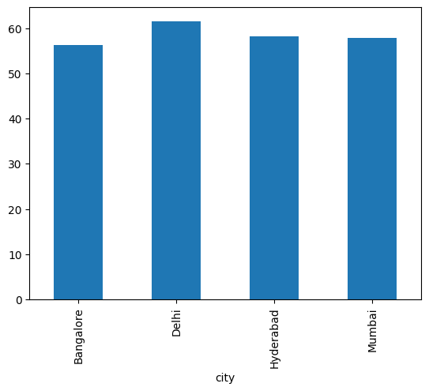

```python
df.groupby("city")["occ_pct"].mean().plot(kind='bar')
```

**> better occupancy: weekday or weekend?**

```python
df.head()
```

|  | property_id | check_in_date | room_category | successful_bookings | capacity | occ_pct | room_class | property_name | category | city |
| --- | --- | --- | --- | --- | --- | --- | --- | --- | --- | --- |
| 0 | 16559 | 1-May-22 | RT1 | 25 | 30.0 | 83.33 | Standard | Atliq Exotica | Luxury | Mumbai |
| 1 | 19562 | 1-May-22 | RT1 | 28 | 30.0 | 93.33 | Standard | Atliq Bay | Luxury | Bangalore |
| 2 | 19563 | 1-May-22 | RT1 | 23 | 30.0 | 76.67 | Standard | Atliq Palace | Business | Bangalore |
| 3 | 16558 | 1-May-22 | RT1 | 18 | 19.0 | 94.74 | Standard | Atliq Grands | Luxury | Delhi |
| 4 | 17560 | 1-May-22 | RT1 | 28 | 40.0 | 70.00 | Standard | Atliq City | Business | Mumbai |

```python
df_date
```

|  | date | mmm yy | week no | day_type |
| --- | --- | --- | --- | --- |
| 0 | 01-May-22 | May 22 | W 19 | weekend |
| 1 | 02-May-22 | May 22 | W 19 | weekeday |
| 2 | 03-May-22 | May 22 | W 19 | weekeday |
| 3 | 04-May-22 | May 22 | W 19 | weekeday |
| 4 | 05-May-22 | May 22 | W 19 | weekeday |
| ... | ... | ... | ... | ... |
| 87 | 27-Jul-22 | Jul 22 | W 31 | weekeday |
| 88 | 28-Jul-22 | Jul 22 | W 31 | weekeday |
| 89 | 29-Jul-22 | Jul 22 | W 31 | weekeday |
| 90 | 30-Jul-22 | Jul 22 | W 31 | weekend |
| 91 | 31-Jul-22 | Jul 22 | W 32 | weekend |

92 rows × 4 columns

```python
df=pd.merge(df,df_date, left_on="check_in_date", right_on="date")
df.head(3)
```

|  | property_id | check_in_date | room_category | successful_bookings | capacity | occ_pct | room_class | property_name | category | city | date | mmm yy | week no | day_type |
| --- | --- | --- | --- | --- | --- | --- | --- | --- | --- | --- | --- | --- | --- | --- |
| 0 | 19563 | 10-May-22 | RT3 | 15 | 29.0 | 51.72 | Premium | Atliq Palace | Business | Bangalore | 10-May-22 | May 22 | W 20 | weekeday |
| 1 | 18560 | 10-May-22 | RT1 | 19 | 30.0 | 63.33 | Standard | Atliq City | Business | Hyderabad | 10-May-22 | May 22 | W 20 | weekeday |
| 2 | 19562 | 10-May-22 | RT1 | 18 | 30.0 | 60.00 | Standard | Atliq Bay | Luxury | Bangalore | 10-May-22 | May 22 | W 20 | weekeday |

```python
df.groupby("day_type")["occ_pct"].mean().round(2)
```

```
day_type
weekeday    50.88
weekend     72.34
Name: occ_pct, dtype: float64
```

inference: weekend occupancy better

**> data filtering:on specific month**

```python
df["mmm yy"].unique()
```

```
array(['May 22', 'Jun 22', 'Jul 22'], dtype=object)
```

```python
df_jun_22=df[df["mmm yy"]=="Jun 22"]
df_jun_22.head(4)
```

|  | property_id | check_in_date | room_category | successful_bookings | capacity | occ_pct | room_class | property_name | category | city | date | mmm yy | week no | day_type |
| --- | --- | --- | --- | --- | --- | --- | --- | --- | --- | --- | --- | --- | --- | --- |
| 2200 | 16559 | 10-Jun-22 | RT1 | 20 | 30.0 | 66.67 | Standard | Atliq Exotica | Luxury | Mumbai | 10-Jun-22 | Jun 22 | W 24 | weekeday |
| 2201 | 19562 | 10-Jun-22 | RT1 | 19 | 30.0 | 63.33 | Standard | Atliq Bay | Luxury | Bangalore | 10-Jun-22 | Jun 22 | W 24 | weekeday |
| 2202 | 19563 | 10-Jun-22 | RT1 | 17 | 30.0 | 56.67 | Standard | Atliq Palace | Business | Bangalore | 10-Jun-22 | Jun 22 | W 24 | weekeday |
| 2203 | 17558 | 10-Jun-22 | RT1 | 9 | 19.0 | 47.37 | Standard | Atliq Grands | Luxury | Mumbai | 10-Jun-22 | Jun 22 | W 24 | weekeday |

```python
df_jun_22.groupby("city")["occ_pct"].mean().round(2)
```

```
city
Bangalore    56.44
Delhi        62.47
Hyderabad    58.46
Mumbai       58.38
Name: occ_pct, dtype: float64
```

```python
df_jun_22.groupby("city")["occ_pct"].mean().round(2).sort_values(ascending=False)
```

```
city
Delhi        62.47
Hyderabad    58.46
Mumbai       58.38
Bangalore    56.44
Name: occ_pct, dtype: float64
```

**> appending new month data to existing data**

```python
df_august=pd.read_csv("datasets/new_data_august.csv")
df_august.head()
```

|  | property_id | property_name | category | city | room_category | room_class | check_in_date | mmm yy | week no | day_type | successful_bookings | capacity | occ% |
| --- | --- | --- | --- | --- | --- | --- | --- | --- | --- | --- | --- | --- | --- |
| 0 | 16559 | Atliq Exotica | Luxury | Mumbai | RT1 | Standard | 01-Aug-22 | Aug-22 | W 32 | weekeday | 30 | 30 | 100.00 |
| 1 | 19562 | Atliq Bay | Luxury | Bangalore | RT1 | Standard | 01-Aug-22 | Aug-22 | W 32 | weekeday | 21 | 30 | 70.00 |
| 2 | 19563 | Atliq Palace | Business | Bangalore | RT1 | Standard | 01-Aug-22 | Aug-22 | W 32 | weekeday | 23 | 30 | 76.67 |
| 3 | 19558 | Atliq Grands | Luxury | Bangalore | RT1 | Standard | 01-Aug-22 | Aug-22 | W 32 | weekeday | 30 | 40 | 75.00 |
| 4 | 19560 | Atliq City | Business | Bangalore | RT1 | Standard | 01-Aug-22 | Aug-22 | W 32 | weekeday | 20 | 26 | 76.92 |

```python
df_august.columns
```

```
Index(['property_id', 'property_name', 'category', 'city', 'room_category',
       'room_class', 'check_in_date', 'mmm yy', 'week no', 'day_type',
       'successful_bookings', 'capacity', 'occ%'],
      dtype='object')
```

```python
df.columns
```

```
Index(['property_id', 'check_in_date', 'room_category', 'successful_bookings',
       'capacity', 'occ_pct', 'room_class', 'property_name', 'category',
       'city', 'date', 'mmm yy', 'week no', 'day_type'],
      dtype='object')
```

```python
df_august.shape
```

```
(7, 13)
```

```python
df.shape
```

```
(6497, 14)
```

```python
latest_df=pd.concat([df,df_august], ignore_index=True, axis=0)
latest_df.tail(10)
```

|  | property_id | check_in_date | room_category | successful_bookings | capacity | occ_pct | room_class | property_name | category | city | date | mmm yy | week no | day_type | occ% |
| --- | --- | --- | --- | --- | --- | --- | --- | --- | --- | --- | --- | --- | --- | --- | --- |
| 6494 | 17558 | 31-Jul-22 | RT4 | 3 | 6.0 | 50.0 | Presidential | Atliq Grands | Luxury | Mumbai | 31-Jul-22 | Jul 22 | W 32 | weekend | NaN |
| 6495 | 19563 | 31-Jul-22 | RT4 | 3 | 6.0 | 50.0 | Presidential | Atliq Palace | Business | Bangalore | 31-Jul-22 | Jul 22 | W 32 | weekend | NaN |
| 6496 | 17561 | 31-Jul-22 | RT4 | 3 | 4.0 | 75.0 | Presidential | Atliq Blu | Luxury | Mumbai | 31-Jul-22 | Jul 22 | W 32 | weekend | NaN |
| 6497 | 16559 | 01-Aug-22 | RT1 | 30 | 30.0 | NaN | Standard | Atliq Exotica | Luxury | Mumbai | NaN | Aug-22 | W 32 | weekeday | 100.00 |
| 6498 | 19562 | 01-Aug-22 | RT1 | 21 | 30.0 | NaN | Standard | Atliq Bay | Luxury | Bangalore | NaN | Aug-22 | W 32 | weekeday | 70.00 |
| 6499 | 19563 | 01-Aug-22 | RT1 | 23 | 30.0 | NaN | Standard | Atliq Palace | Business | Bangalore | NaN | Aug-22 | W 32 | weekeday | 76.67 |
| 6500 | 19558 | 01-Aug-22 | RT1 | 30 | 40.0 | NaN | Standard | Atliq Grands | Luxury | Bangalore | NaN | Aug-22 | W 32 | weekeday | 75.00 |
| 6501 | 19560 | 01-Aug-22 | RT1 | 20 | 26.0 | NaN | Standard | Atliq City | Business | Bangalore | NaN | Aug-22 | W 32 | weekeday | 76.92 |
| 6502 | 17561 | 01-Aug-22 | RT1 | 18 | 26.0 | NaN | Standard | Atliq Blu | Luxury | Mumbai | NaN | Aug-22 | W 32 | weekeday | 69.23 |
| 6503 | 17564 | 01-Aug-22 | RT1 | 10 | 16.0 | NaN | Standard | Atliq Seasons | Business | Mumbai | NaN | Aug-22 | W 32 | weekeday | 62.50 |

```python
latest_df.shape
```

```
(6504, 15)
```

**> print revenue realized per city**

```python
df_bookings.head()
```

[output not shown]

```python
df_hotels.head()
```

|  | property_id | property_name | category | city |
| --- | --- | --- | --- | --- |
| 0 | 16558 | Atliq Grands | Luxury | Delhi |
| 1 | 16559 | Atliq Exotica | Luxury | Mumbai |
| 2 | 16560 | Atliq City | Business | Delhi |
| 3 | 16561 | Atliq Blu | Luxury | Delhi |
| 4 | 16562 | Atliq Bay | Luxury | Delhi |

```python
df_bookings_all=pd.merge(df_bookings,df_hotels, on="property_id")
df_bookings_all.head()
```

[output not shown]

```python
df_bookings_all.groupby("city")["revenue_realized"].sum()
```

```
city
Bangalore    420397050
Delhi        294500318
Hyderabad    325232870
Mumbai       668640991
Name: revenue_realized, dtype: int64
```

**> print month by month revenue**

```python
df_bookings_all.head(3)
```

[output not shown]

```python
df_date.head()
```

|  | date | mmm yy | week no | day_type |
| --- | --- | --- | --- | --- |
| 0 | 01-May-22 | May 22 | W 19 | weekend |
| 1 | 02-May-22 | May 22 | W 19 | weekeday |
| 2 | 03-May-22 | May 22 | W 19 | weekeday |
| 3 | 04-May-22 | May 22 | W 19 | weekeday |
| 4 | 05-May-22 | May 22 | W 19 | weekeday |

```python
pd.merge(df_bookings_all, df_date, left_on="check_in_date", right_on="date")
```

[output not shown]

```python
df_bookings_all.info()
```

[output not shown]

```python
df_date.info()
```

```
<class 'pandas.core.frame.DataFrame'>
RangeIndex: 92 entries, 0 to 91
Data columns (total 4 columns):
 #   Column    Non-Null Count  Dtype
---  ------    --------------  -----
 0   date      92 non-null     object
 1   mmm yy    92 non-null     object
 2   week no   92 non-null     object
 3   day_type  92 non-null     object
dtypes: object(4)
memory usage: 3.0+ KB
```

> as the date fields are of object datatype they cannot be merged together, we need to convert them to datetime datatype

```python
df_date["date"] = pd.to_datetime(df_date["date"])
df_date.head(3)
```

|  | date | mmm yy | week no | day_type |
| --- | --- | --- | --- | --- |
| 0 | 2022-05-01 | May 22 | W 19 | weekend |
| 1 | 2022-05-02 | May 22 | W 19 | weekeday |
| 2 | 2022-05-03 | May 22 | W 19 | weekeday |

```python
df_date.info()
```

```
<class 'pandas.core.frame.DataFrame'>
RangeIndex: 92 entries, 0 to 91
Data columns (total 4 columns):
 #   Column    Non-Null Count  Dtype
---  ------    --------------  -----
 0   date      92 non-null     datetime64[ns]
 1   mmm yy    92 non-null     object
 2   week no   92 non-null     object
 3   day_type  92 non-null     object
dtypes: datetime64[ns](1), object(3)
memory usage: 3.0+ KB
```

```python
df_bookings_all["check_in_date"] = pd.to_datetime(df_bookings_all["check_in_date"], format='mixed')
df_bookings_all.head(4)
```

[output not shown]

```python
df_bookings_all.info()
```

[output not shown]

```python
df_bookings_all = pd.merge(df_bookings_all, df_date, left_on="check_in_date", right_on="date")
df_bookings_all.head(3)
```

|  | booking_id | property_id | booking_date | check_in_date | checkout_date | no_guests | room_category | booking_platform | ratings_given | booking_status | revenue_generated | revenue_realized | property_name | category | city | date | mmm yy | week no | day_type |
| --- | --- | --- | --- | --- | --- | --- | --- | --- | --- | --- | --- | --- | --- | --- | --- | --- | --- | --- | --- |
| 0 | May052216558RT11 | 16558 | 15-04-22 | 2022-05-05 | 7/5/2022 | 3.0 | RT1 | tripster | 5.0 | Checked Out | 10010 | 10010 | Atliq Grands | Luxury | Delhi | 2022-05-05 | May 22 | W 19 | weekeday |
| 1 | May052216558RT12 | 16558 | 30-04-22 | 2022-05-05 | 7/5/2022 | 2.0 | RT1 | others | NaN | Cancelled | 9100 | 3640 | Atliq Grands | Luxury | Delhi | 2022-05-05 | May 22 | W 19 | weekeday |
| 2 | May052216558RT13 | 16558 | 1/5/2022 | 2022-05-05 | 6/5/2022 | 3.0 | RT1 | direct offline | 5.0 | Checked Out | 10010 | 10010 | Atliq Grands | Luxury | Delhi | 2022-05-05 | May 22 | W 19 | weekeday |

```python
df_bookings_all.groupby("mmm yy")["revenue_realized"].sum()
```

```
mmm yy
Jul 22    390005772
Jun 22    377191229
May 22    408375641
Name: revenue_realized, dtype: int64
```

^^ month by month revenue result

**> print revenue realized per hotel type**

```python
df_bookings_all.property_name.unique()
```

```
array(['Atliq Grands', 'Atliq Exotica', 'Atliq City', 'Atliq Blu',
       'Atliq Bay', 'Atliq Palace', 'Atliq Seasons'], dtype=object)
```

```python
df_bookings_all.groupby("property_name")["revenue_realized"].sum().round(2).sort_values()
```

```
property_name
Atliq Seasons     45959517
Atliq Grands     145860641
Atliq Blu        179203544
Atliq Bay        179429321
Atliq City       196568883
Atliq Palace     209474575
Atliq Exotica    219076161
Name: revenue_realized, dtype: int64
```

**> print average rating per city**

```python
df_bookings_all.groupby("city")["ratings_given"].mean().round(2).sort_values()
```

```
city
Bangalore    3.40
Mumbai       3.64
Hyderabad    3.66
Delhi        3.77
Name: ratings_given, dtype: float64
```

**> print revenue realized per booking platform**

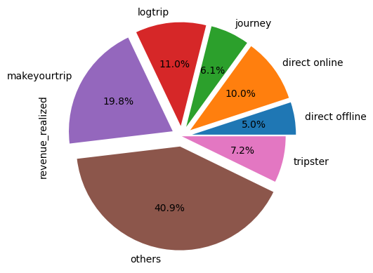

```python
df_bookings_all.groupby("booking_platform")["revenue_realized"].sum().plot(kind='pie', explode=(0.1,0.1,0.1,0.1,0.1,0.1,0), autopct="%1.1f%%")
```